# End of Chapter 1 exercises (Page 39)

*Solution*

```r
pass_m=mean(meap01$math4)
pass_m
```

```
## [1] 71.909
```

```r
pass_r=mean(meap01$read4)
pass_r
```

```
## [1] 60.06188
```

```r
#Cleary Reading is much more difficult to pass
```

**(v) Find the correlation between math4 and read4. What do you conclude?**

*Solution*

```r
cor(meap01$math4,meap01$read4)
```

```
## [1] 0.8427281
```

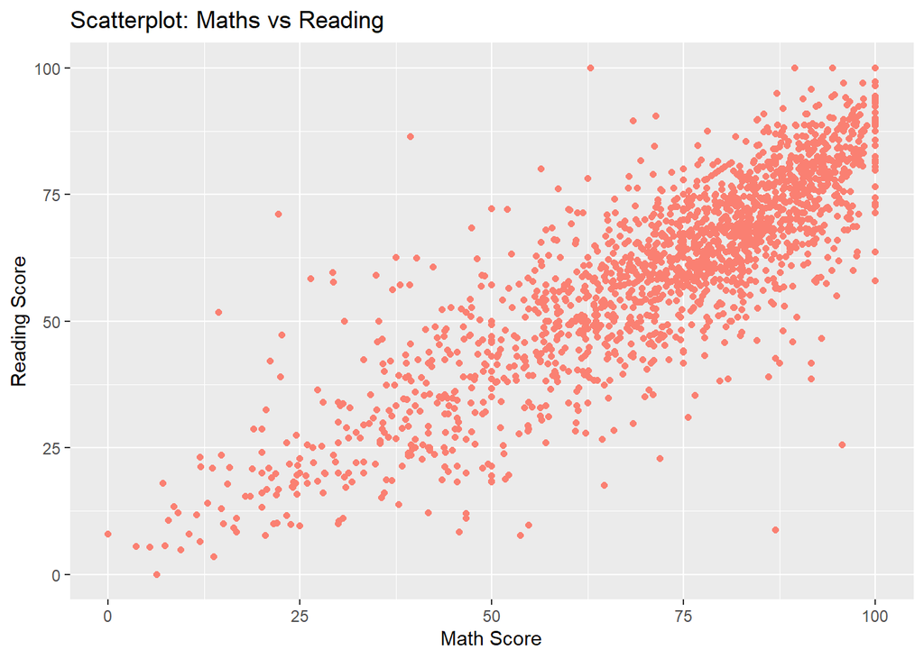

```r
library(ggplot2)
ggplot(data=meap01,aes(x=meap01$math4,y=meap01$read4))+geom_point(col='salmon')+ggtitle("Scatterplot: Maths vs Reading")+xlab("Math Score")+ylab("Reading Score")
```

```r
#It is strongly positive
```

**(vi) The variable exppp is expenditure per pupil. Find the average of exppp along with its standard deviation. Would you say there is wide variation in per pupil spending?**

```r
mean(meap01$exppp)
```

```
## [1] 5194.865
```

```r
sd(meap01$exppp)
```

```
## [1] 1091.89
```

```r
summary(meap01$exppp)
```

```
##    Min. 1st Qu.  Median    Mean 3rd Qu.    Max.
##    1207    4502    5078    5195    5767   11958
```

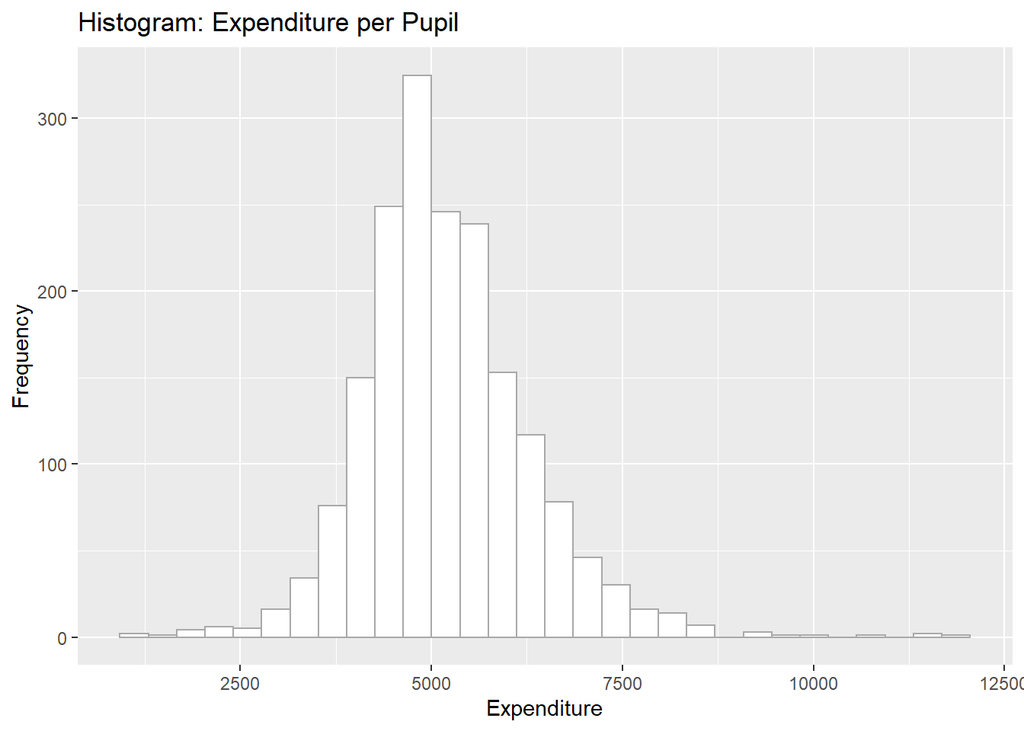

```r
library(ggplot2)
ggplot(data=meap01,aes(x=meap01$exppp))+geom_histogram(col='dark grey',fill='white')+ggtitle("Histogram: Expenditure per Pupil")+xlab("Expenditure")+ylab("Frequency")
```

```r
#Considering Min=1207 and Max=11958, It is significantly wide
```

**(vii) Suppose School A spends $6,000 per student and School B spends $5,500 per student. By what percentage does School A’s spending exceed School B’s? Compare this to 100 · [log(6,000) – log(5,500)], which is the approximation percentage difference based on the difference in the natural logs. (See Section A.4 in Appendix A.)**

*Solution*

```r
round((log(6000)-log(5500))*100,2) # Gives the Percentage
```

```
## [1] 8.7
```

```r
round(((6000-5500)/ 5500)*100,2)
```

```
## [1] 9.09
```

**C4: The data in JTRAIN2 come from a job training experiment conducted for low-income men during 1976–1977; see Lalonde (1986).**

```r
head(jtrain2)
```

```
##   train age educ black hisp married nodegree mosinex re74 re75     re78 unem74
## 1     1  37   11     1    0       1        1      13    0    0  9.93005      1
## 2     1  22    9     0    1       0        1      13    0    0  3.59589      1
## 3     1  30   12     1    0       0        0      13    0    0 24.90950      1
## 4     1  27   11     1    0       0        1      13    0    0  7.50615      1
## 5     1  33    8     1    0       0        1      13    0    0  0.28979      1
## 6     1  22    9     1    0       0        1      13    0    0  4.05649      1
##   unem75 unem78 lre74 lre75     lre78 agesq mostrn
## 1      1      0     0     0  2.295566  1369     13
## 2      1      0     0     0  1.279792   484     13
## 3      1      0     0     0  3.215249   900     13
## 4      1      0     0     0  2.015723   729     13
## 5      1      0     0     0 -1.238599  1089     13
## 6      1      0     0     0  1.400318   484     13
```

```r
?jtrain2
```

**(i) Use the indicator variable train to determine the fraction of men receiving job training.**

*Solution*

```r
tr=nrow(jtrain2 %>% group_by(train) %>% filter(train=='1'))
tr
```

```
## [1] 185
```

```r
total=nrow(jtrain2)
total
```

```
## [1] 445
```

```r
percent_trained=round((tr/total)*100,2)
percent_trained
```

```
## [1] 41.57
```

**(ii) The variable re78 is earnings from 1978, measured in thousands of 1982 dollars. Find the averages of re78 for the sample of men receiving job training and the sample not receiving job training. Is the difference economically large?**